# N2O ePS + ePSproc preliminary multi-orb analysis: core 1s events (pt 1)

29/09/20

15/11/20 - modified for N(1s) threshold, [for 550 - 620eV see original version on ePSdata](https://phockett.github.io/ePSdata/N2O-preliminary/N2O_1s_core_preliminary_ePSproc_290920.html).

Paul Hockett

*** Preliminary results.

## Background

Basic analysis of N2O ePolyScat results for core ionization events, O(1s) and N(1s). For backgound and methods, see [ePSdata overview](https://phockett.github.io/ePSdata/about.html), [ePSdata methods](https://phockett.github.io/ePSdata/methods.html) and [ePS/ePSproc tutorial docs](https://epsproc.readthedocs.io/en/latest/ePS_ePSproc_tutorial/ePS_tutorial_080520.html).

Pt 1: analysis of basic photoionization properties and matrix elements (this doc).

Pt 2: angle-resolved observables (in progress).

To do list:

- Check electronic structure outputs vs. known thresholds. (From fig. 4 in the PRP it looks like the O(1s) results are shifted up by ~20eV, TBC.)
- Analyse ePS computational precision (via gauge results).
- Estimate accuracy of photoionization properties by comparison with experimental data. (Cf. [recent XeF2 results](https://phockett.github.io/ePSdata/XeF2-preliminary/XeF2_multi-orb_comparisons_270320-dist.html#Comparison-with-expt.) - good, but required ~9eV energy shift, reasons TBC.)
- Finish pt 2.

## Setup

### Env

```python
!hostname
```

```
Stimpy
```

```python
!conda env list
```

```
# conda environments:
#
                         C:\Program Files (x86)\Microsoft Visual Studio\Shared\Anaconda3_64
                         C:\Program Files (x86)\Microsoft Visual Studio\Shared\Anaconda3_64\envs\dataVis3D
                         C:\Program Files (x86)\Microsoft Visual Studio\Shared\Anaconda3_64\envs\dataVis3D-yt
                         C:\Program Files (x86)\Microsoft Visual Studio\Shared\Anaconda3_64\envs\ePSdev
                         C:\Program Files (x86)\Microsoft Visual Studio\Shared\Anaconda3_64\envs\ePSpkgTest2
                         C:\Program Files (x86)\Microsoft Visual Studio\Shared\Anaconda3_64\envs\fibre-sim
                         C:\Program Files (x86)\Microsoft Visual Studio\Shared\Anaconda3_64\envs\ipykernel_py2
                         C:\Program Files (x86)\Microsoft Visual Studio\Shared\Anaconda3_64\envs\pkgTest
                         C:\Program Files (x86)\Microsoft Visual Studio\Shared\Anaconda3_64\envs\pypi-test
                         C:\Program Files (x86)\Microsoft Visual Studio\Shared\Anaconda3_64\envs\seabreeze-bk
                         C:\Program Files (x86)\Microsoft Visual Studio\Shared\Anaconda3_64\envs\test
base                     C:\ProgramData\Anaconda3
ePSdev                   C:\Users\femtolab\.conda\envs\ePSdev
epsInstallTest           C:\Users\femtolab\.conda\envs\epsInstallTest
epsdev                *  C:\Users\femtolab\.conda\envs\epsdev
seabreeze                C:\Users\femtolab\AppData\Local\conda\conda\envs\seabreeze
tensorflow               C:\Users\femtolab\AppData\Local\conda\conda\envs\tensorflow
```

### Load modules

```python
import sys
import os
from pathlib import Path
import numpy as np
# import epsproc as ep
import xarray as xr

from datetime import datetime as dt
timeString = dt.now()
```

```python
# For module testing, include path to module here, otherwise use global installation
if sys.platform == "win32":
    modPath = r'D:\code\github\ePSproc'  # Win test machine
    winFlag = True
else:
    modPath = r'/home/femtolab/github/ePSproc/'  # Linux test machine
    winFlag = False

sys.path.append(modPath)
import epsproc as ep
# # TODO: tidy this up!
# from epsproc.util import matEleSelector
# from epsproc.geomFunc import geomCalc, geomUtils
# from epsproc.geomFunc.lfblmGeom import lfblmXprod

# Plotters
from epsproc.plot import hvPlotters

# Multijob class dev code
from epsproc.classes.multiJob import ePSmultiJob
```

```
* pyevtk not found, VTK export not available.
```

```python
hvPlotters.setPlotters()
# import bokeh
# import holoviews as hv
# hv.extension('bokeh')
```

### Load data

```python
# # Scan for subdirs, based on existing routine in getFiles()
fileBase = r'D:\VMs\Share\ePSshare\N2O\N20_wf'  # Test dir on Stimpy (Win machine)
```

```python
N2Odata = ePSmultiJob(fileBase, verbose = 0)
keys = [0,1,2]  # Set for 1s datasets only (ugly!)
N2Odata.scanFiles(keys = keys)
N2Odata.jobsSummary()
```

```
Found 3 directories, with 21 files.

*** Job orb1 details
Key: orb1
Dir D:\VMs\Share\ePSshare\N2O\N20_wf\orb1_S, 7 files.
{   'batch': 'ePS N2O, batch N2O_wf, orbital orb1_S',
    'event': 'orb 1 ionization (O 1s, S/A1).',
    'orbE': -562.219888836424,
    'orbLabel': 'O 1s, S/A1'}

*** Job orb2 details
Key: orb2
Dir D:\VMs\Share\ePSshare\N2O\N20_wf\orb2_S, 7 files.
{   'batch': 'ePS N2O, batch N2O_wf, orbital orb2_S',
    'event': 'orb 2 ionization (N 1s, S/A1).',
    'orbE': -431.308631832806,
    'orbLabel': 'N 1s, S/A1'}

*** Job orb3 details
Key: orb3
Dir D:\VMs\Share\ePSshare\N2O\N20_wf\orb3_S, 7 files.
{   'batch': 'ePS N2O, batch N2O_wf, orbital orb3_S',
    'event': 'orb 3 ionization (N 1s, S/A1).',
    'orbE': -427.26774100883597,
    'orbLabel': 'N 1s, S/A1'}
```

## System properties

Here orbitals 1,2,3 are all core 1s orbitals, centred on:

1. O
2. N (central)
3. N (terminal)

```
*** Molecular structure
```

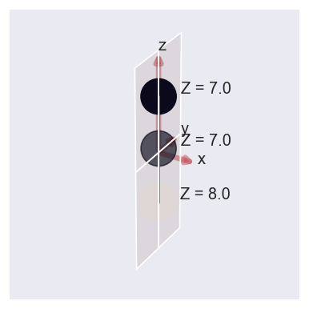

```
*** Molecular orbital list (from ePS output file)
EH = Energy (Hartrees), E = Energy (eV), NOrbGrp, OrbGrp, GrpDegen = degeneracies and corresponding orbital numbering by group in ePS, NormInt = single centre expansion convergence (should be ~1.0).
```

| props orb | Sym | EH | Occ | E | NOrbGrp | OrbGrp | GrpDegen | NormInt |
| --- | --- | --- | --- | --- | --- | --- | --- | --- |
| 1 | S | -20.6612 | 2.0 | -562.219889 | 1.0 | 1.0 | 1.0 | 0.979634 |
| 2 | S | -15.8503 | 2.0 | -431.308632 | 1.0 | 2.0 | 1.0 | 0.999998 |
| 3 | S | -15.7018 | 2.0 | -427.267741 | 1.0 | 3.0 | 1.0 | 0.983661 |
| 4 | S | -1.6338 | 2.0 | -44.457962 | 1.0 | 4.0 | 1.0 | 0.999465 |
| 5 | S | -1.4519 | 2.0 | -39.508211 | 1.0 | 5.0 | 1.0 | 0.999243 |
| 6 | S | -0.8306 | 2.0 | -22.601777 | 1.0 | 6.0 | 1.0 | 0.999545 |
| 7 | P | -0.7759 | 2.0 | -21.113314 | 1.0 | 7.0 | 2.0 | 0.999991 |
| 8 | P | -0.7759 | 2.0 | -21.113314 | 2.0 | 7.0 | 2.0 | 0.999991 |
| 9 | S | -0.6985 | 2.0 | -19.007153 | 1.0 | 8.0 | 1.0 | 0.999692 |
| 10 | P | -0.4961 | 2.0 | -13.499569 | 1.0 | 9.0 | 2.0 | 0.999984 |
| 11 | P | -0.4961 | 2.0 | -13.499569 | 2.0 | 9.0 | 2.0 | 0.999984 |

```
*** Warning: some orbital convergences outside single-center expansion convergence tolerance (0.01):
[[1.         0.97963433]
 [3.         0.98366107]]
```

```python
N2Odata.molSummary()
```

```python
# Quick manual fix for orb/job labels

N2Odata.jobLabel(key='orb2', lString = "(central)")
N2Odata.jobLabel(key='orb3', lString = "(terminal)")
```

## Plot cross-sections and betas

These are from ePolyScat's `getCro` function, and are LF (unaligned ensemble) results. This provides a good, if general, overview.

### Overview (all symmetries)

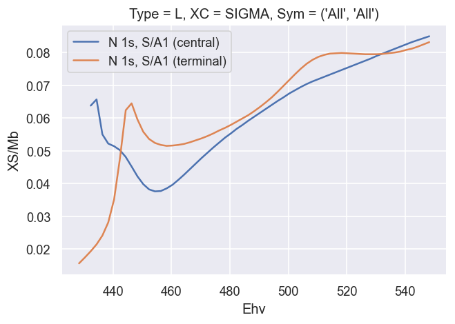

```python
# Comparitive plot over datasets (all symmetries only)
Erange=[400, 550]
N2Odata.plotGetCroComp(pType='SIGMA', Etype='Ehv', Erange=Erange)
```

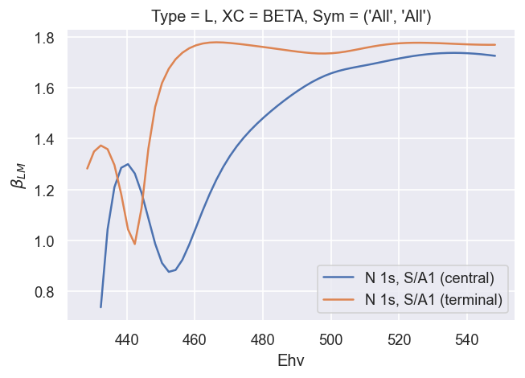

```python
# Comparitive plot over datasets (all symmetries only)
N2Odata.plotGetCroComp(pType='BETA', Etype='Ehv', Erange=Erange)
```

These are fairly broad statements, the matrix elements will be examined in more detail below...

### Continua and gauge specific results

This gives an idea of the relative contributions of different symmetry channels, and the variation in the results between length (L) and velocity (V) gauge results, hence computational accuracy.

- The allowed symmetries are S ($\sigma$) and P ($\pi$).
- The (continuum) symmetries are correlated with parallel or perpendicular polarization geometries in the molecular frame ($\mu=0$ and $\mu=\pm1$ respectively). In the lab frame (LF) or aligned frame (AF) these will be mixed to some degree, depending on the alignment.

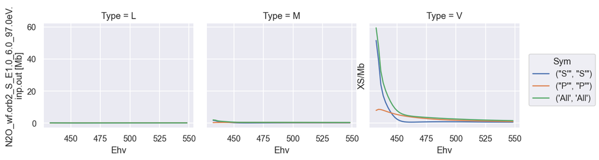

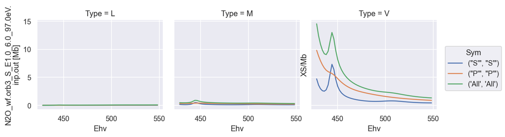

```python
N2Odata.plotGetCro(pType='SIGMA', Etype='Ehv', Erange=Erange)
```

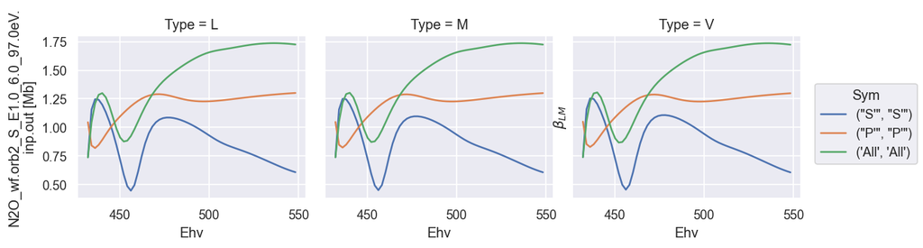

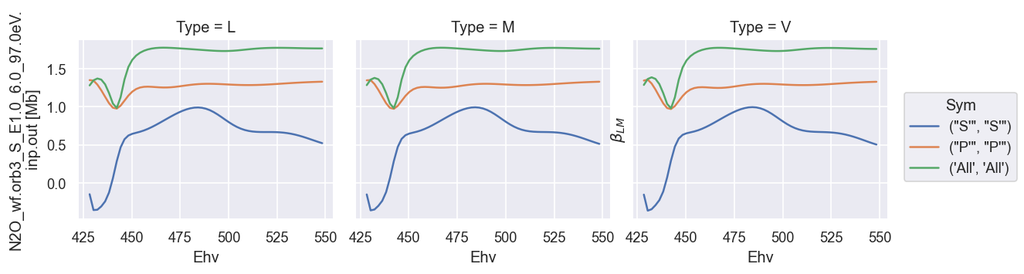

```python
N2Odata.plotGetCro(pType='BETA', Etype='Ehv', Erange=Erange)
```

```python
# Interactive version of the above.
# Here the L, V gauges are shown as dashed lines, and the mixed gauge solid. Both sigma and beta data is shown.
# Mouse-over plots for data details, and use controls in top corner.

hvPlotters.setPlotters(width=800)
N2Odata.plotGetCro(Etype='Ehv', Erange=Erange, backend = 'hv')
```

```
*** N 1s, S/A1
```

[interactive chart not shown]

```
*** N 1s, S/A1
```

[interactive chart not shown]

## Raw matrix elements

Below are strip-charts showing the raw matrix elements for each channel (abs values) and symmetry group.

Here:

- The matrix elements are indexed by (Symmetry, l, m, mu), where (l,m) are the usual partial-wave indicies (corresponding to photoelectron angular momentum), and mu defines the photon angular momentum.
- The symmetries are labelled as Cont(inuum), Targ(et) and Total, corresponding to [the definitions here](https://epsproc.readthedocs.io/en/latest/ePS_ePSproc_tutorial/ePS_tutorial_080520.html#Worked-example:-N2-3\sigma_g^{-1}).
- The allowed symmetries are S ($\sigma$) and P ($\pi$).
- The (continuum) symmetries are correlated with parallel or perpendicular polarization geometries in the molecular frame ($\mu=0$ and $\mu=\pm1$ respectively). In the lab frame (LF) or aligned frame (AF) these will be mixed to some degree, depending on the alignment.

### Abs values

The plots are thresholded based on the abs values, at 10% of the maximum value (per channel), and values below threshold are greyed out.

```
Plotting data N2O_wf.orb2_S_E1.0_6.0_97.0eV.inp.out, pType=a, thres=0.03381427021166804, with Seaborn
Plotting data N2O_wf.orb3_S_E1.0_6.0_97.0eV.inp.out, pType=a, thres=0.018736579963286943, with Seaborn
```

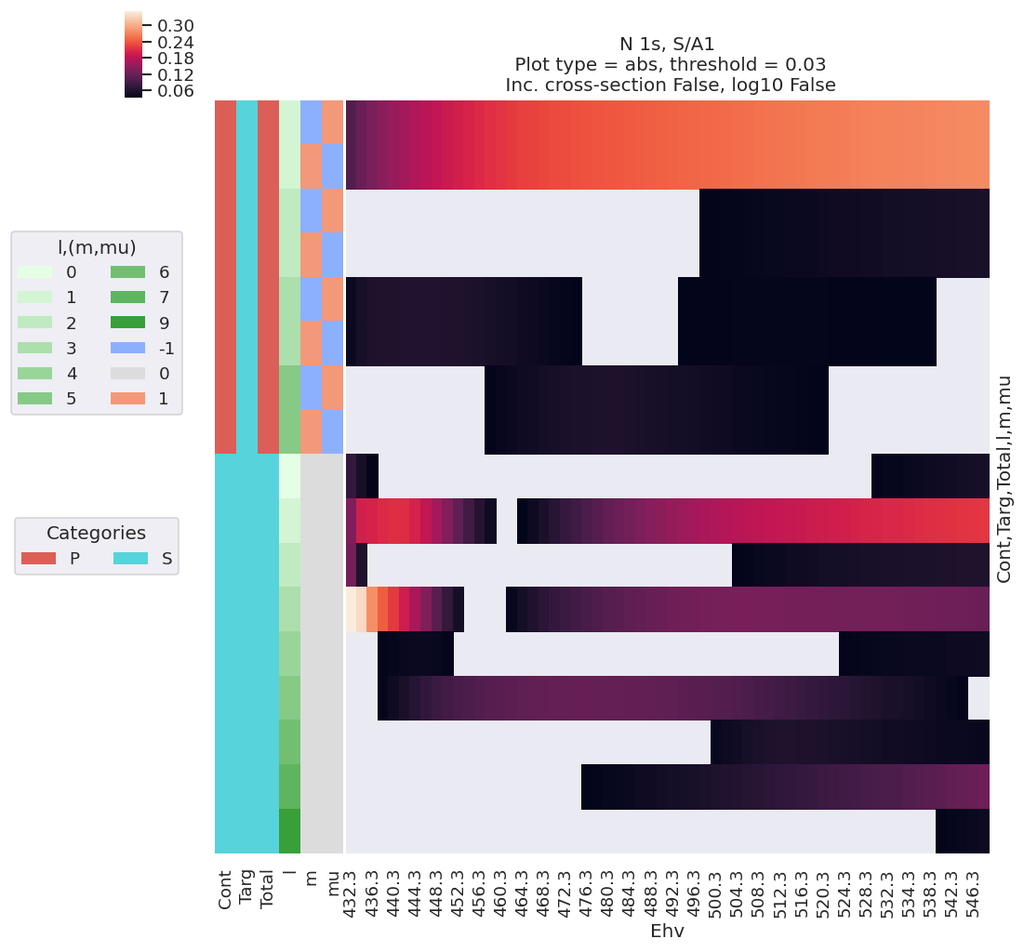

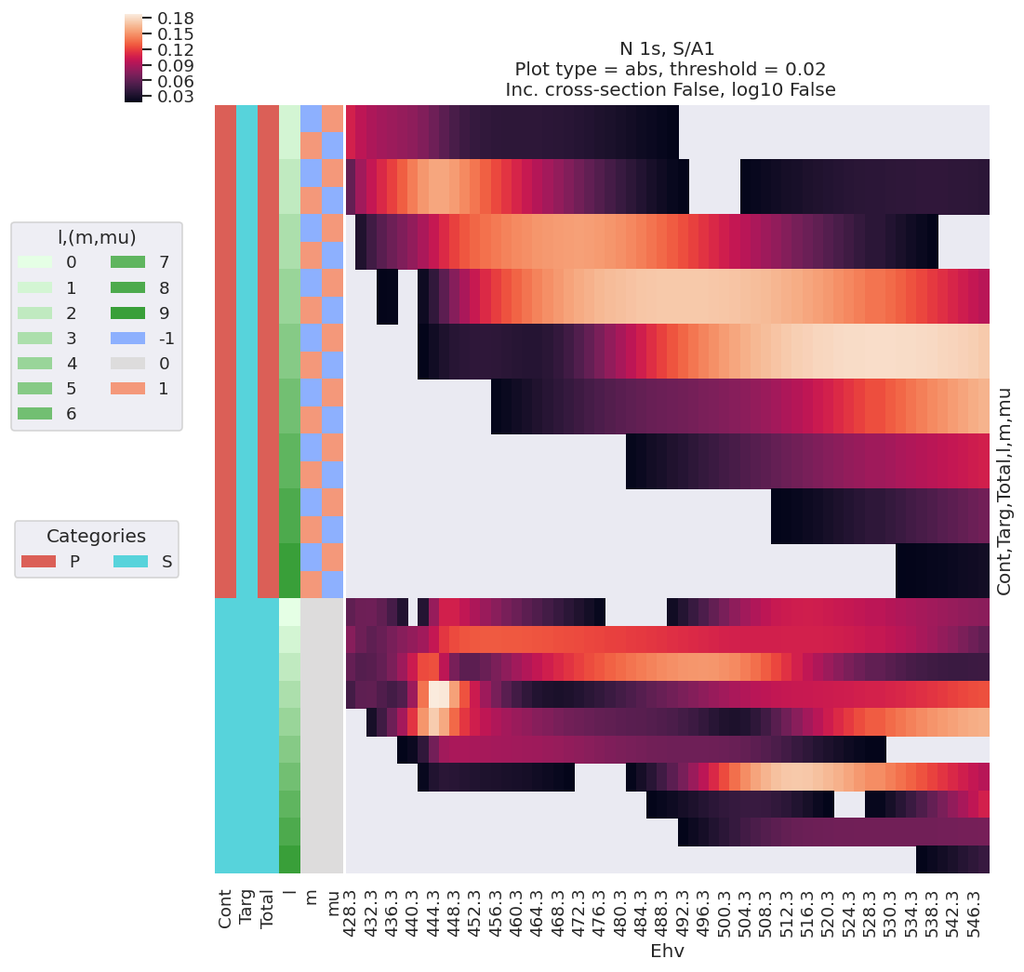

```python
N2Odata.lmPlotOpts = {'selDims' : {'Type':'L', 'it' : 1}, 'fillna' : False, 'thres' : 0.1, 'thresType' : 'pc', 'SFflag' : False}
N2Odata.lmPlot(Etype='Ehv', Erange=Erange)
```

### Phases

And the phases... (with unwrapping).

```
Plotting data N2O_wf.orb2_S_E1.0_6.0_97.0eV.inp.out, pType=phaseUW, thres=0.03381427021166804, with Seaborn
```

```
Plotting data N2O_wf.orb3_S_E1.0_6.0_97.0eV.inp.out, pType=phaseUW, thres=0.018736579963286943, with Seaborn
```

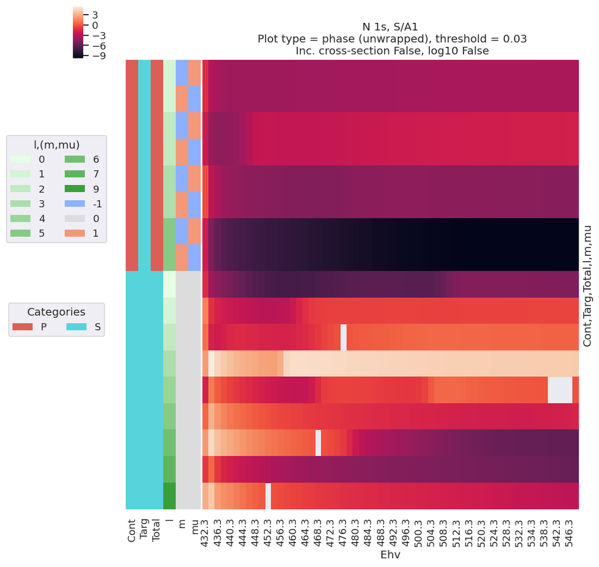

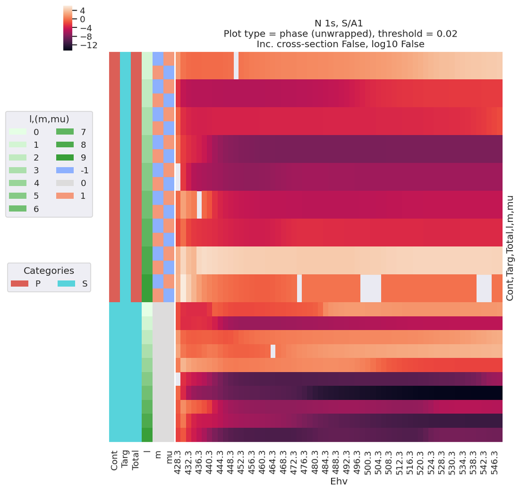

```python
N2Odata.lmPlot(Etype='Ehv', Erange=Erange, pType='phaseUW')
```

## Matix element difference plots

```python
Erange = [563, 620]  # Clip Erange to > O(1s) threshold for diff plotting

# N2Odata.lmPlotOpts = {'selDims' : {'Type':'L', 'it' : 1, 'Cont':'S', 'Total':'S'}, 'fillna' : False, 'thres' : None, 'SFflag' : False}
# N2Odata.lmPlotOpts = {'selDims' : {'Type':'L', 'it' : 1}, 'fillna' : True, 'thres' : 0.1, 'SFflag' : False}
N2Odata.lmPlot(Etype='Ehv', Erange=Erange, refDataKey = [0,0], reindexTol=1.0, keys=[1,2], pType='phaseUW')
```

[output not shown]

## Versions

```python
import scooby
scooby.Report(additional=['epsproc', 'xarray', 'jupyter'])
```

[output not shown]

## Appendix - tabulated values

For reference... source files will be uploaded to Zenodo soon.

```python
N2Odata.matEtoPD(xDim = 'Ehv', Erange=Erange, thres=0.1, selDims = {'Type':'L'}) #TODO ADD Ehv swap, Erange
```

[output not shown]